# Examples of map layers

# nrcan

`plotRGB(openmap(x,path="nrcan"))`

Cartography by Open Government Licence - Canada.

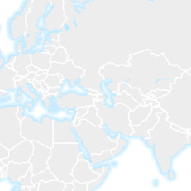

[figure not shown]

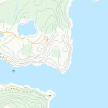

# nrcan-text

`plotRGB(openmap(x,path="nrcan-text"))`

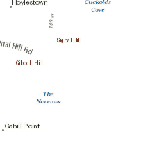

# nrcan-text-fr

`plotRGB(openmap(x,path="nrcan-text-fr"))`

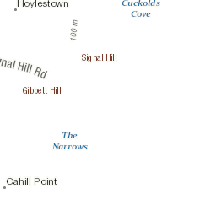

# stamen-toner

`plotRGB(openmap(x,path="stamen-toner"))`

Map tiles by [Stamen Design](http://stamen.com) under [CC BY 3.0](http://creativecommons.org/licenses/by/3.0). Data by [OpenStreetMap](http://openstreetmap.org), available under the [Open Database License](http://opendatacommons.org/licenses/odbl)

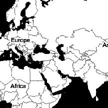

[figure not shown]

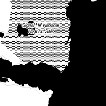

# stamen-watercolor

`plotRGB(openmap(x,path="stamen-watercolor"))`

Map tiles by [Stamen Design](http://stamen.com) under [CC BY 3.0](http://creativecommons.org/licenses/by/3.0). Data by [OpenStreetMap](http://openstreetmap.org), available under the [CC BY-SA](http://creativecommons.org/licenses/by/3.0)

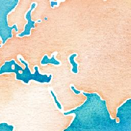

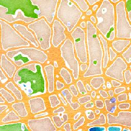

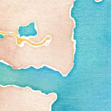